# HW3

Peiran Chen

4/30/2022

## 1.

### a.

```r
set.seed(123)
y <- rnorm(100)
x <- matrix(rnorm(10000*100), ncol=10000)

lm_1a <- lm(y ~ x)
```

In matrix form, we could rewrite our expression as:

$$\begin{align*}
Y &= \beta_0 + \beta_1 X_1 + \beta_2X_2 + .... + \beta_{10000}X_{10000} + \varepsilon, \text{ where } \varepsilon \sim N(0,1) \\
Y &= \beta X + \varepsilon \\
\intertext{And Least Squares will give us}\\
\hat Y &= \hat\beta X + \varepsilon\\
\intertext{Hence, it's MSE is}\\
MSE &= E[Y - \hat Y]^2\\
&= Var[\varepsilon] + Bias^2[\hat f(x_0)] + Var[\hat f(x_0)]
\end{align*}$$

### b.

As we can see, that $Var[\varepsilon]$ is irreducible, because it exists in nature, and we know that it is caused by the randomness in our $y$, which is just $1$.

### c.

#### i.

$$Bias = \sqrt{\left(E[\hat f(x_0)] - f(x_0)\right)^2} = f(x_0)$$
Because we have $f(x) = y \sim N(0,1)$. Thus, we have the Bias is equal to 0.

#### ii.

```r
fc <- rep(0,100)
(variance <- (sd(fc))^2)
```

```
## [1] 0
```

Thus, the variance for this procedure is 0.

#### iii.

In this case,

$$EPE = Var[\varepsilon] + Bias^2[\hat f(x_0)] + Var[\hat f(x_0)] = Var[\varepsilon] = 1$$
And our $Bias^2[\hat f(x)] = 0$, and $Var[\hat f(x)] = 0$. And $Var[\varepsilon] = 1$, we have = 1.

#### iv.

With Validation Set Approach, we first scramble the data set into train and validation, and then, then, with $\hat f_{\text{train}}(\text{validation} \ x) = 0$. It’s
$$CV_{VSA} = \frac1n\sum_{i \in \text{validation set}}(\hat f_{\text{train}}(x_i) - y_i)^2 = E[y_i^2] = Var[y_i] + E[y_i]^2 = 1$$
.

#### v.

I found out that they do match with each other. And the reason for that is because we have set that $f(x) = 0 x $.

### d.

```r
set.seed(123)
train <- sample(100, 50)
train.x <- x[train, ]
val.x <- x[-train, ]

train.y <- y[train]
val.y <- y[-train]
lm_2 <- lm(train.y ~ train.x)
mean((val.y - predict.lm(lm_2, data.frame(val.x)))^2)
```

```
## [1] 1.906787
```

### e.

4. has a smaller estimated Test Error, but higher variance and bias.

## 2.

### a.

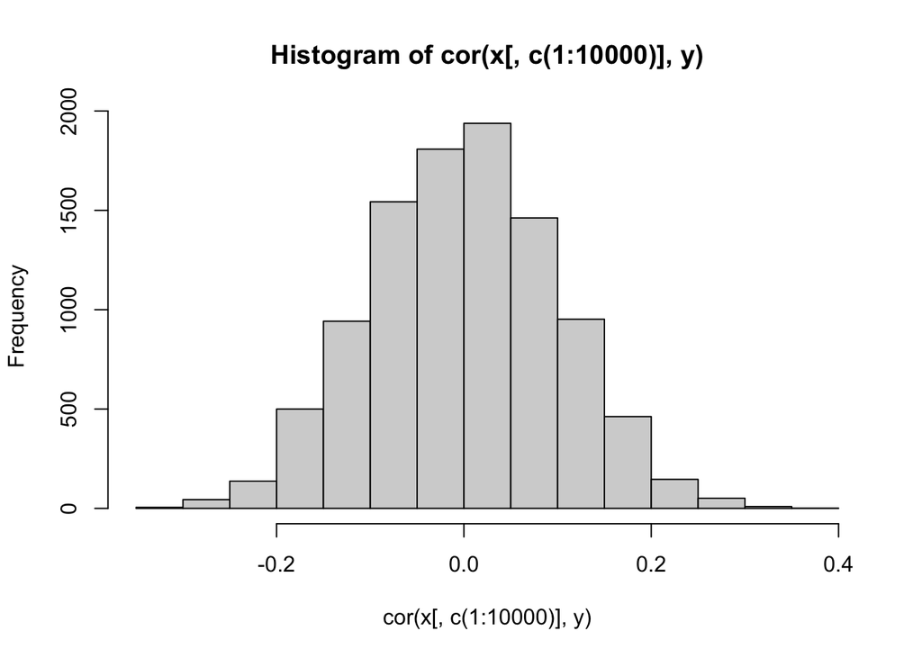

```r
hist(cor(x[,c(1:10000)],y))
```

```r
df <- tibble("index" = c(1:10000),
             "Correlation" = abs(cor(x[,c(1:10000)],y)))

top_10 <- top_n(df, 10, Correlation)
```

### b.

```r
set.seed(123)
train <- sample(100, 50)
train.x <- x[train, ]
val.x <- x[-train, ]

train.y <- y[train]
val.y <- y[-train]

lm_3 <- lm(train.y ~ train.x[,top_10$index])
mean((val.y - predict.lm(lm_3, data.frame(val.x[,top_10$index]))) ^ 2)
```

```
## [1] 1.574802
```

### c.

```r
set.seed(123)
train <- sample(100, 50)
train.x <- x[train, ]
val.x <- x[-train, ]

train.y <- y[train]
val.y <- y[-train]

df_new <- tibble("index" = c(1:10000),
             "Correlation" = cor(train.x[,c(1:10000)],train.y))

top_10_new <- top_n(df_new, 10, Correlation)

lm_4 <- lm(train.y ~ train.x[,top_10_new$index])
mean((val.y - predict.lm(lm_4, data.frame(val.x[,top_10_new$index]))) ^ 2)
```

```
## [1] 1.626437
```

### d.

In our finding, we found out that with the same $q = 10$ features, “Option 1” gave us a better estimated test error.

## 3.

### a.

I choose a data set that is called “Superconductivty Data Data Set”. It has $p = 81$ features. And the goal is to use all the features(extracted from the superconductor’s chemical formula) to predict the superconducting critical temperature.

### b.

```r
df <- read.csv("train.csv")

set.seed(123)
# We would first split the data into train & val sets
train <- sample(21263, 10632)

df_train <- df[train, ]
df_val <- df[-train, ]

lm_5 <- lm(critical_temp ~.-critical_temp, data = df_train)
test_error <- mean((df_val$critical_temp - predict.lm(lm_5, df_val[1:81])) ^ 2)
```

The test error(Test MSE) is 306.3443086. And I first use Validation Set Approach to split the data into train/validation set about half and half(10632:10631). Then, I perform Least Squares on the training data. And calculate the Test Error using validation set data.

### c.

```r
lambdas <- 10^seq(10, -2, length=100)
ridge_mod <- glmnet(as.matrix(df_train[1:81]), as.matrix(df_train[82]), alpha = 0, lambda = lambdas)

dim(coef(ridge_mod))
```

```
## [1]  82 100
```

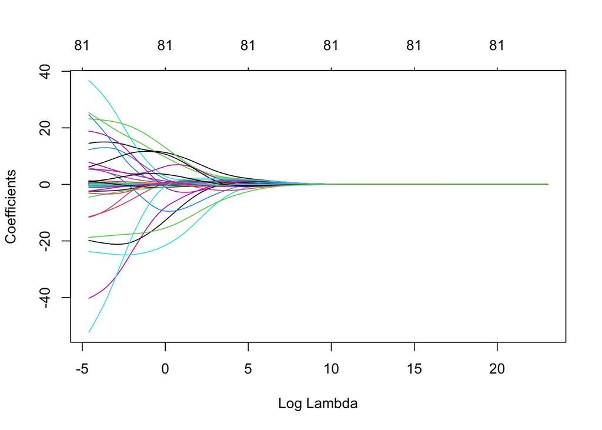

```r
plot(ridge_mod, xvar="lambda")
```

### d.

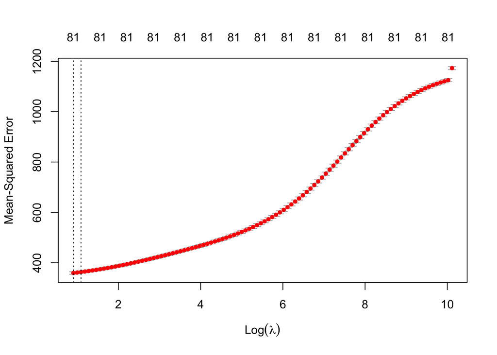

```r
cv.out <- cv.glmnet(as.matrix(df[1:81]), as.matrix(df[82]), alpha = 0)
plot(cv.out)
```

```r
best_lambda <- cv.out$lambda.min

smallest_test_error <- min(cv.out$cvm)
```

When $\lambda =$ 2.47061, we will have the smallest test error of 359.0993455.

### e.

```r
lambdas <- 10^seq(10, -2, length=100)
lasso_mod <- glmnet(as.matrix(df_train[1:81]), as.matrix(df_train[82]), alpha = 1, lambda = lambdas)

dim(coef(lasso_mod))
```

```
## [1]  82 100
```

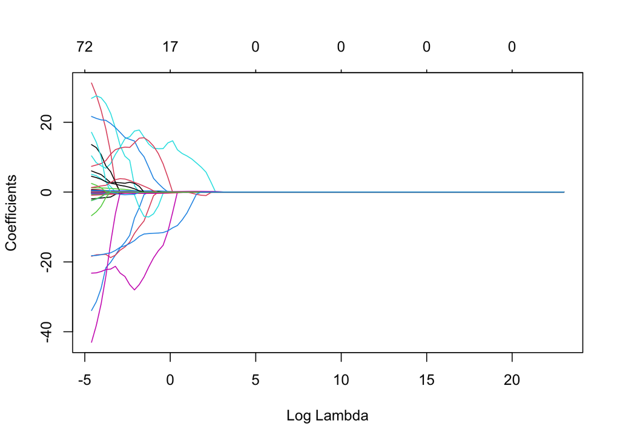

```r
plot(lasso_mod, xvar="lambda")
```

### f.

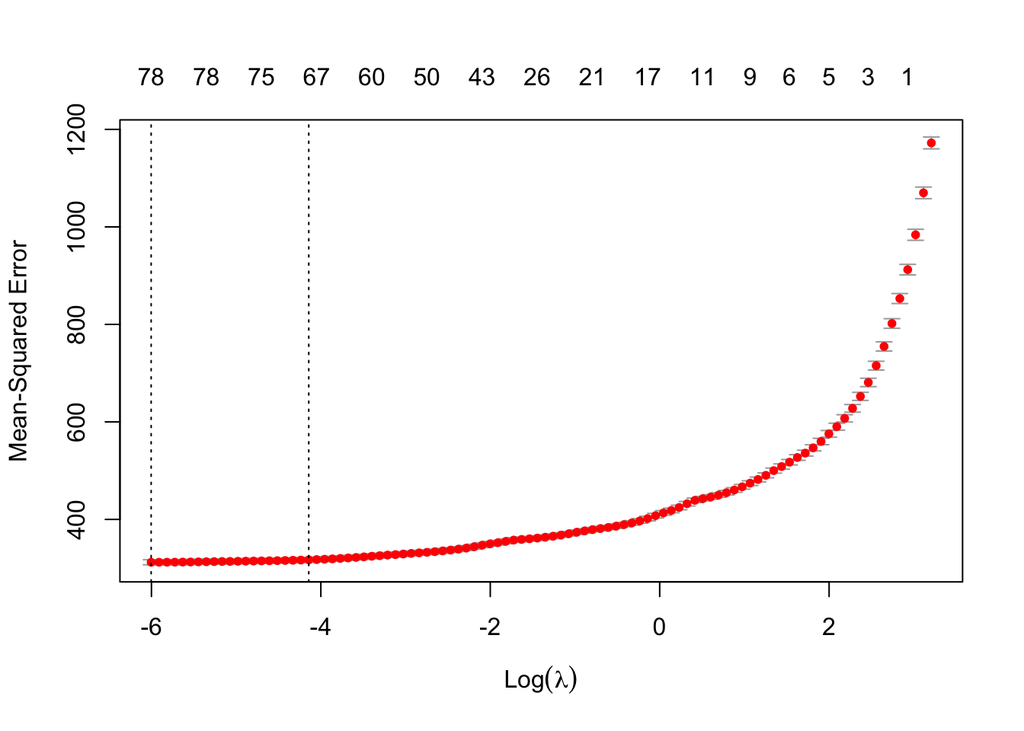

```r
cv.out <- cv.glmnet(as.matrix(df[1:81]), as.matrix(df[82]), alpha = 1)
plot(cv.out)
```

```r
best_lambda <- cv.out$lambda.min

smallest_test_error <- min(cv.out$cvm)

coef(cv.out, s=best_lambda)
```

```
## 82 x 1 sparse Matrix of class "dgCMatrix"
##                                            s1
## (Intercept)                     -1.863123e+01
## number_of_elements              -3.712175e+00
## mean_atomic_mass                 4.681039e-01
## wtd_mean_atomic_mass            -4.009149e-01
## gmean_atomic_mass               -1.488603e-01
## wtd_gmean_atomic_mass            1.692463e-01
## entropy_atomic_mass             -3.515285e+01
## wtd_entropy_atomic_mass          7.526031e+00
## range_atomic_mass                2.027316e-01
## wtd_range_atomic_mass            1.599796e-02
## std_atomic_mass                 -3.357037e-01
## wtd_std_atomic_mass             -1.519477e-01
## mean_fie                         2.551794e-03
## wtd_mean_fie                     1.454059e-02
## gmean_fie                       -9.377466e-04
## wtd_gmean_fie                    5.784444e-03
## entropy_fie                     -9.077222e+00
## wtd_entropy_fie                  4.009666e+01
## range_fie                        6.454953e-02
## wtd_range_fie                    1.818315e-02
## std_fie                         -1.649075e-01
## wtd_std_fie                     -2.571322e-02
## mean_atomic_radius               7.352046e-01
## wtd_mean_atomic_radius           1.203987e+00
## gmean_atomic_radius             -1.021587e+00
## wtd_gmean_atomic_radius         -8.471990e-01
## entropy_atomic_radius            .
## wtd_entropy_atomic_radius        3.457795e+01
## range_atomic_radius              2.299207e-01
## wtd_range_atomic_radius         -8.925065e-02
## std_atomic_radius               -9.455527e-01
## wtd_std_atomic_radius            2.613079e-01
## mean_Density                    -4.182863e-03
## wtd_mean_Density                -6.588360e-04
## gmean_Density                    5.411907e-04
## wtd_gmean_Density                2.796627e-03
## entropy_Density                  1.417015e+01
## wtd_entropy_Density             -1.572851e+01
```

[output cut: 29 more lines]

```
## wtd_entropy_ThermalConductivity  3.054302e+00
## range_ThermalConductivity       -8.039620e-02
## wtd_range_ThermalConductivity   -2.100160e-01
## std_ThermalConductivity          2.334896e-01
## wtd_std_ThermalConductivity      1.556576e-02
## mean_Valence                     .
## wtd_mean_Valence                 2.349723e-04
## gmean_Valence                    4.471047e+00
## wtd_gmean_Valence               -4.455900e+00
## entropy_Valence                  4.594607e+01
## wtd_entropy_Valence             -6.485796e+01
## range_Valence                    4.799753e+00
## wtd_range_Valence                3.775408e-01
## std_Valence                      .
## wtd_std_Valence                 -1.928312e+01
```

Best lambda in this case is 0.0024706, we will have the smallest test error of 312.1169266. As we can see from above, this time, LASSO model uses all features except “entropy_atomic_radius”, “mean_Valence”, and “std_Valence”.

## 4.

### a.

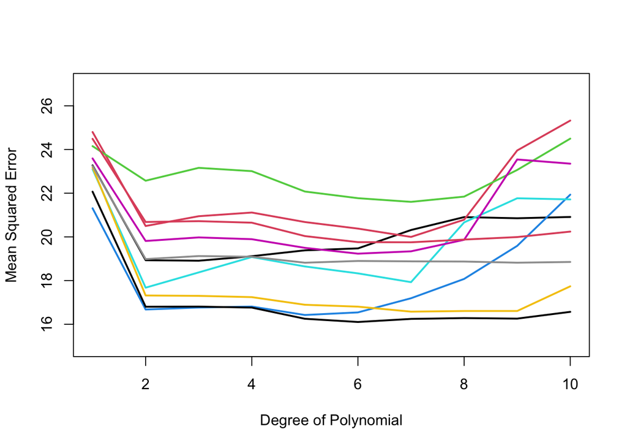

```r
data(Auto)
# Split data
set.seed(435)
degrees <- c(1:10)
train <- sample(392, 196)
test_MSE <- matrix(NA, 10, 10)
for(i in degrees){
  lm.fit <- lm(mpg ~ poly(horsepower, i), data = Auto, subset = train)
  test_MSE[1, i] <- mean((Auto$mpg - predict(lm.fit, Auto))[-train] ^ 2)
}

plot(x = degrees, y = test_MSE[1, ],
     lwd = 2,
     type = "l",
     lty = 1,
     ylim = c(15,27),
     xlab = "Degree of Polynomial",
     ylab = "Mean Squared Error")


for (i in 2:10) {
  train <- sample(392, 196)
  for (j in degrees) {
    lm.fit <- lm(mpg ~ poly(horsepower, j),
                 data = Auto,
                 subset = train)
    test_MSE[i, j] <- mean((Auto$mpg - predict(lm.fit, Auto))[-train] ^ 2)
  }
  lines(x = degrees, y = test_MSE[i, ], col = i,
        lty = 1,
        lwd = 2)
}
```

```r
kable(tibble(
  Degree = degrees,
  "Mean Validation MSE" = rowMeans(test_MSE)
))
```

| Degree | Mean Validation MSE |
| --- | --- |
| 1 | 20.20745 |
| 2 | 21.84832 |
| 3 | 22.77518 |
| 4 | 18.13227 |
| 5 | 19.72755 |
| 6 | 20.81062 |
| 7 | 17.62689 |
| 8 | 19.35863 |
| 9 | 17.01602 |
| 10 | 20.62025 |

As we can see from the above table, Mean Test MSE is the smallest when degree is at 9. Hence, it is the best.

## b.

```r
# LOOCV
set.seed(435)
cv_error <- rep(NA, 10)

for( i in 1:10){
  glm.fit <- glm(mpg ~ poly(horsepower, i), data = Auto)
  cv_error[i] <- cv.glm(Auto, glm.fit)$delta[1]
}

kable(tibble(
  Degree = degrees,
  "LOOCV" = cv_error
))
```

| Degree | LOOCV |
| --- | --- |
| 1 | 24.23151 |
| 2 | 19.24821 |
| 3 | 19.33498 |
| 4 | 19.42443 |
| 5 | 19.03321 |
| 6 | 18.97864 |
| 7 | 18.83305 |
| 8 | 18.96115 |
| 9 | 19.06863 |
| 10 | 19.49093 |

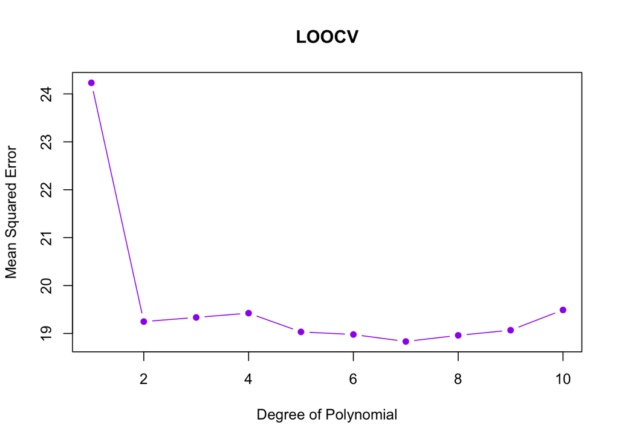

```r
plot(x = degrees,
     y = cv_error,
     xlab = "Degree of Polynomial",
     ylab = "Mean Squared Error",
     main = "LOOCV",
     col = "purple",
     type = "b",
     pch = 16)
```

With LOOCV, the lowest error occurs at Degree equals 7.

### c.

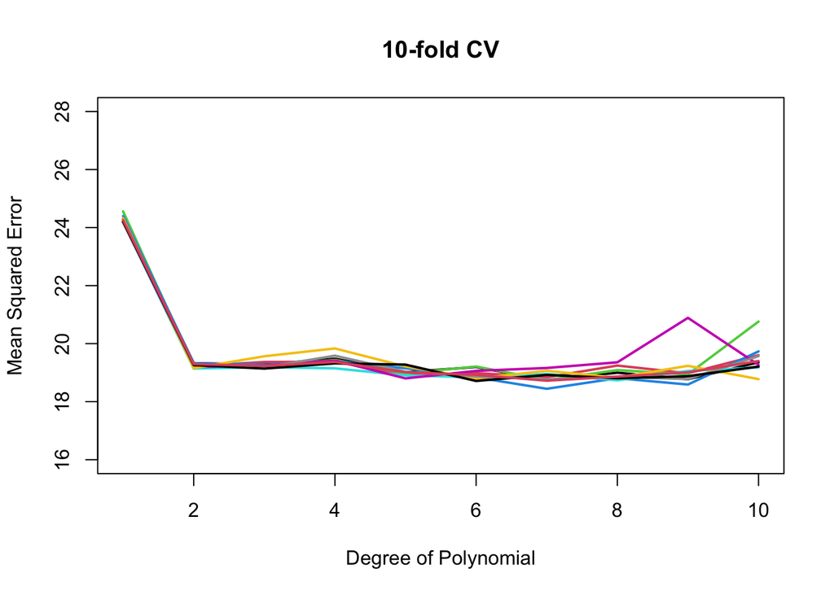

```r
set.seed(435)

cv_error_10 <- matrix(0, 10, 10)

for (i in 1:10) {
  glm.fit <- glm(mpg ~ poly(horsepower, i), data = Auto)
  cv_error_10[1, i] <- cv.glm(Auto, glm.fit, K = 10)$delta[1]
}
plot(
  x = c(1:10),
  y = cv_error_10[1,],
  lty = 1,
  type = "l",
  lwd = 2,
  ylim = c(16, 28),
  xlab = "Degree of Polynomial",
  ylab = "Mean Squared Error",
  main = "10-fold CV"
)


for (i in 2:10) {
  for (j in 1:10) {
    glm.fit <- glm(mpg ~ poly(horsepower, j), data = Auto)
    cv_error_10[i, j] <- cv.glm(Auto, glm.fit, K = 10)$delta[1]
  }
  lines(x = c(1:10), y = cv_error_10[i, ],
        col = i,
        lwd = 2)
}
```

```r
kable(tibble(
  Degree = degrees,
  "Mean Validation MSE" = rowMeans(cv_error_10)
))
```

| Degree | Mean Validation MSE |
| --- | --- |
| 1 | 19.64669 |
| 2 | 19.67251 |
| 3 | 19.81529 |
| 4 | 19.59466 |
| 5 | 19.53472 |
| 6 | 19.85939 |
| 7 | 19.67893 |
| 8 | 19.60792 |
| 9 | 19.57428 |
| 10 | 19.60936 |

At degree equals to 5, we have the smallest mean 10 fold CV error.

### d.

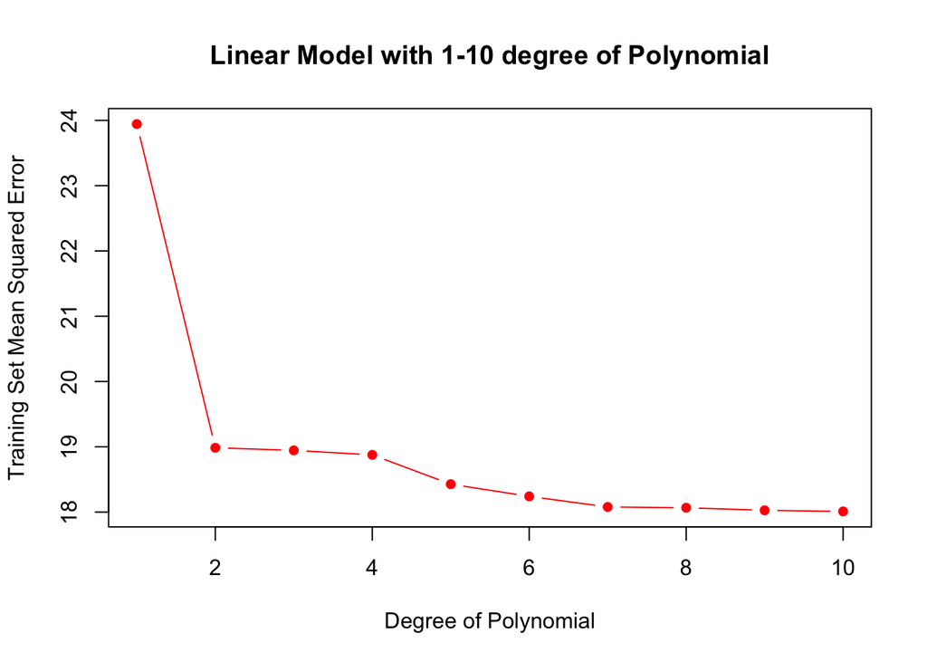

```r
set.seed(435)
degrees <- c(1:10)
train_MSE <- rep(NA, 10)

for(i in degrees){
  lm.fit <- lm(mpg ~ poly(horsepower, i), data = Auto)
  train_MSE[i] <- mean(lm.fit$residuals^2)
}

plot(x = degrees,
     y = train_MSE,
     xlab = "Degree of Polynomial",
     ylab = "Training Set Mean Squared Error",
     main = "Linear Model with 1-10 degree of Polynomial",
     col = "red",
     type = "b",
     pch = 16)
```

```r
kable(tibble(
  Degree = degrees,
  "Mean Validation MSE" = train_MSE
))
```

| Degree | Mean Validation MSE |
| --- | --- |
| 1 | 23.94366 |
| 2 | 18.98477 |
| 3 | 18.94499 |
| 4 | 18.87633 |
| 5 | 18.42697 |
| 6 | 18.24065 |
| 7 | 18.07817 |
| 8 | 18.06613 |
| 9 | 18.02697 |
| 10 | 18.00953 |

With increase in Degree of Polynomial, our Training MSE will monotonically decrease, and the smallest Train MSE occurred at $degree = 10$.

### e.

```r
set.seed(435)

lm.fit <- lm(mpg ~ poly(horsepower, 10), data = Auto)
summary(lm.fit)
```

```
##
## Call:
## lm(formula = mpg ~ poly(horsepower, 10), data = Auto)
##
## Residuals:
##      Min       1Q   Median       3Q      Max
## -15.7081  -2.5904  -0.1922   2.2859  14.8338
##
## Coefficients:
##                         Estimate Std. Error t value Pr(>|t|)
## (Intercept)              23.4459     0.2174 107.840   <2e-16 ***
## poly(horsepower, 10)1  -120.1377     4.3046 -27.909   <2e-16 ***
## poly(horsepower, 10)2    44.0895     4.3046  10.242   <2e-16 ***
## poly(horsepower, 10)3    -3.9488     4.3046  -0.917   0.3595
## poly(horsepower, 10)4    -5.1878     4.3046  -1.205   0.2289
## poly(horsepower, 10)5    13.2722     4.3046   3.083   0.0022 **
## poly(horsepower, 10)6    -8.5462     4.3046  -1.985   0.0478 *
## poly(horsepower, 10)7     7.9806     4.3046   1.854   0.0645 .
## poly(horsepower, 10)8     2.1727     4.3046   0.505   0.6140
## poly(horsepower, 10)9    -3.9182     4.3046  -0.910   0.3633
## poly(horsepower, 10)10   -2.6146     4.3046  -0.607   0.5440
## ---
## Signif. codes:  0 '***' 0.001 '**' 0.01 '*' 0.05 '.' 0.1 ' ' 1
##
## Residual standard error: 4.305 on 381 degrees of freedom
## Multiple R-squared:  0.7036, Adjusted R-squared:  0.6958
## F-statistic: 90.45 on 10 and 381 DF,  p-value: < 2.2e-16
```

## 5.

### a.

$$\begin{align*}
\arg\min_\beta \sum_{i = 1}^n (y_i - \beta x_i)^2 = \frac{\partial}{\partial\beta}\sum_{i = 1}^n (y_i - \beta x_i)^2 &= 0\\
-2 \sum_{i = 1}^n x_i(y_i - \beta x_i) &= 0\\
\sum_{i = 1}^n x_iy_i - \beta\sum_{i = 1}^n x_i^2&= 0\\
\hat\beta^{L.S.} = \frac{\sum_{i = 1}^n x_iy_i}{\sum_{i = 1}^n x_i^2}
\end{align*}$$

### b.

$$\begin{align*}
\arg\min_\beta \sum_{i = 1}^n (y_i - \beta x_i)^2 + \lambda\beta^2 = \frac{\partial}{\partial\beta}\left[\sum_{i = 1}^n (y_i - \beta x_i)^2 + \lambda\beta^2\right] &= 0\\
-2 \sum_{i = 1}^n x_i(y_i - \beta x_i) + 2\lambda\beta&= 0\\
\sum_{i = 1}^n x_iy_i - \beta\sum_{i = 1}^n x_i^2 &= \lambda\beta\\
\beta\left(\sum_{i = 1}^n x_i^2 + \lambda\right) &= \sum_{i = 1}^n x_iy_i\\
\hat\beta^{L.S.} &= \frac{\sum_{i = 1}^n x_iy_i}{\sum_{i = 1}^n x_i^2 + \lambda}\\
\end{align*}$$

### c.

From part a),

$$\begin{align*}
E[\hat\beta^{L.S.}] &= E\left[\frac{\sum_{i = 1}^n x_iy_i}{\sum_{i = 1}^n x_i^2}\right] \\
&= E\left[\frac{\sum_{i = 1}^n x_i(3x_i + \varepsilon))}{\sum_{i = 1}^n x_i^2}\right] \\
&= E\left[\frac{\sum_{i = 1}^n 3x_i^2 + \varepsilon \sum_{i = 1}^nx_i}{\sum_{i = 1}^n x_i^2}\right] \\
\intertext{Since } X \text{ and } \varepsilon \text{ are independent}\\
&= \frac{3E[\sum_{i = 1}^n x_i^2] + E[\varepsilon] \times E[\sum_{i = 1}^nx_i]}{E[\sum_{i = 1}^n x_i^2]} \\
&= \frac{3E[\sum_{i = 1}^n x_i^2] }{E[\sum_{i = 1}^n x_i^2]} \\
&= 3 = \beta
\end{align*}$$

Hence, $\hat\beta$ is an unbiased estimator of $\beta$.

### d.

$$\begin{align*}
E[\hat\beta^{ridge}] &= E\left[\frac{\sum_{i = 1}^n x_iy_i}{\sum_{i = 1}^n x_i^2 + \lambda}\right]\\
&= E\left[\frac{\sum_{i = 1}^n x_i(3x_i + \varepsilon))}{\sum_{i = 1}^n x_i^2+ \lambda}\right] \\
&= E\left[\frac{\sum_{i = 1}^n 3x_i^2 + \varepsilon \sum_{i = 1}^nx_i}{\sum_{i = 1}^n x_i^2+ \lambda}\right] \\
\intertext{Since } X \text{ and } \varepsilon \text{ are independent}\\
&= \frac{3E[\sum_{i = 1}^n x_i^2] + E[\varepsilon] \times E[\sum_{i = 1}^nx_i]}{E[\sum_{i = 1}^n x_i^2] + E[\lambda]} \\
&= \frac{3E[\sum_{i = 1}^n x_i^2]}{E[\sum_{i = 1}^n x_i^2] + E[\lambda]} \\
\intertext{Since x is fixed, and lambda is a constant}\\
&= \frac{3\sum_{i = 1}^n x_i^2}{\sum_{i = 1}^n x_i^2 + \lambda} \\
\end{align*}$$

Hence, we have shown that Ridge regression will give us a biased estimator $\hat\beta^{ridge}$ for $\beta$. However, as $\lambda \to 0$, we will have an less biased estimator for $\beta$. And finally when $E[\lambda] = 0$, $\hat\beta^{ridge}$ will be unbiased.

### e.

$$\begin{align*}
Var[\hat\beta^{L.S.}] &= E\left[\hat\beta - E[\hat\beta]\right]^2\\
&=E[\hat\beta - \beta]^2\\
&=E\left[\frac{\sum_{i = 1}^n 3x_i^2 + \varepsilon \sum_{i = 1}^nx_i}{\sum_{i = 1}^n x_i^2} - 3\right]^2 \\
&=E\left[\frac{\varepsilon \sum_{i = 1}^nx_i}{\sum_{i = 1}^n x_i^2} \right]^2 \\
&= \frac{1}{\sum_{i = 1}^n x_i^4}E\left[ \left(\sum_{i = 1}^n\varepsilon x_i\right)^2\right]\\
&= \frac{1}{\sum_{i = 1}^n x_i^4}E\left[ \left(x_1\varepsilon + x_2\varepsilon + ... + x_n\varepsilon\right)^2\right]\\
&= \frac{1}{\sum_{i = 1}^n x_i^4}E\left[x_1^2\varepsilon^2 + x_2^2\varepsilon^2 + ... + x_n^2\varepsilon^2 + 2x_1x_2\varepsilon^2+... + 2x_{n-1}x_n\varepsilon^2\right]\\
&= \frac{E[\varepsilon^2]}{\sum_{i = 1}^n x_i^4} E[x_1^2 + x_2^2+ ... + x_n^2 + 2x_1x_2+... + 2x_{n-1}x_n]\\
\text{Because we are given } &Cov(\varepsilon_i, \varepsilon_i') = 0 \ \forall i \neq i'\\
&= \frac{E[\varepsilon^2]}{\sum_{i = 1}^n x_i^4} E[x_1^2 + x_2^2+ ... + x_n^2]\\
&= \frac{Var[\varepsilon] + E[\varepsilon]^2}{\sum_{i = 1}^n x_i^4}\sum_{i = 1}^n x_i^2\\
&= \frac{\sigma^2}{\sum_{i = 1}^n x_i^2}
\end{align*}$$

### f.

$$\begin{align*}
Var[\hat\beta^{ridge}] &= E\left[\hat\beta^{ridge} - E[\hat\beta^{ridge}]\right]^2\\
&=E\left[\frac{\sum_{i = 1}^n 3x_i^2 + \sum_{i = 1}^n \varepsilon_ix_i}{\sum_{i = 1}^n x_i^2 + \lambda} - \frac{3\sum_{i = 1}^n x_i^2}{\sum_{i = 1}^n x_i^2 + \lambda}\right]^2\\
&=E\left[\frac{ \sum_{i = 1}^n \varepsilon_ix_i}{\sum_{i = 1}^n x_i^2 + \lambda} \right]^2 \\
&= \frac{1}{(\sum_{i = 1}^n x_i^2 + \lambda)^2}E\left[ \left(\sum_{i = 1}^n\varepsilon x_i\right)^2\right]\\
&= \frac{1}{(\sum_{i = 1}^n x_i^2 + \lambda)^2}E\left[ \left(x_1\varepsilon + x_2\varepsilon + ... + x_n\varepsilon\right)^2\right]\\
&= \frac{1}{(\sum_{i = 1}^n x_i^2 + \lambda)^2}E\left[x_1^2\varepsilon^2 + x_2^2\varepsilon^2 + ... + x_n^2\varepsilon^2 + 2x_1x_2\varepsilon^2+... + 2x_{n-1}x_n\varepsilon^2\right]\\
&= \frac{E[\varepsilon^2]}{(\sum_{i = 1}^n x_i^2 + \lambda)^2} E[x_1^2 + x_2^2+ ... + x_n^2 + 2x_1x_2+... + 2x_{n-1}x_n]\\
\text{Because we are given } &Cov(\varepsilon_i, \varepsilon_i') = 0 \ \forall i \neq i'\\
&= \frac{E[\varepsilon^2]}{(\sum_{i = 1}^n x_i^2 + \lambda)^2} E[x_1^2 + x_2^2+ ... + x_n^2]\\
&= \frac{Var[\varepsilon] + E[\varepsilon]^2}{(\sum_{i = 1}^n x_i^2 + \lambda)^2}\sum_{i = 1}^n x_i^2\\
&= \frac{\sigma^2}{(\sum_{i = 1}^n x_i^2 + \lambda)^2}\sum_{i = 1}^n x_i^2
\end{align*}$$

### g.

So we have

$$\begin{align*}
Bias[\hat\beta^{ridge}] &= E[\hat\beta^{ridge}] - \beta\\
&= \frac{3\sum_{i = 1}^n x_i^2}{\sum_{i = 1}^n x_i^2 + \lambda} - 3\\
&= 3\left(\frac{\sum_{i = 1}^n x_i^2}{\sum_{i = 1}^n x_i^2 + \lambda} - \frac{\sum_{i = 1}^n x_i^2 + \lambda}{\sum_{i = 1}^n x_i^2 + \lambda}\right)\\
&= 3 \frac{-\lambda}{\sum_{i = 1}^n x_i^2 + \lambda}\\
Bias^2[\hat\beta^{ridge}] &= 9\frac{\lambda^2}{(\sum_{i = 1}^n x_i^2 + \lambda)^2}\\
\end{align*}$$

And suppose we have $\sum_{i = 1}^n x_i^2 = 10$, $\sigma = 1$.

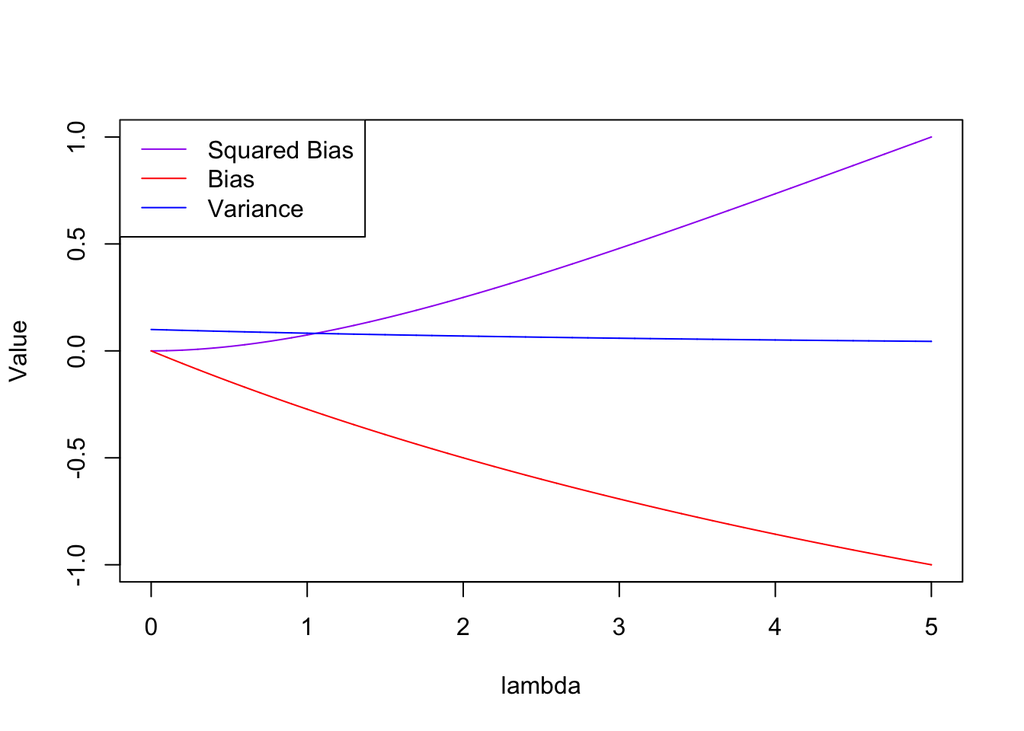

```r
x <- 10
lambda <- seq(0, 5, by = 0.001)
sigma <- 1
plot(lambda, (-3*lambda/(x + lambda))^2, type = "l", col = "purple",
     ylab = "Value", ylim = c(-1,1))
lines(lambda, -3*lambda/(x + lambda), type = "l", col = "red")
lines(lambda, 10*(sigma^2/(10 + lambda)^2), col = "blue")
legend("topleft",
       c("Squared Bias", "Bias", "Variance"),
       col = c("purple", "red", "blue"),
       lty = 1)
```